# Modeling and prediction for movies

Bayesian Regression

Anna Loznevaia

2022-02-06

```r
knitr::opts_chunk$set(warning=FALSE, message=FALSE)
knitr::opts_chunk$set(rows.print=25)
```

## Setup

### Load packages

```r
library(ggplot2)
library(dplyr)
library(GGally)
library(BAS)
library(cowplot)
```

## Part 1: Data

### Research question

The research question was given in a closed form as follows:

Develop a Bayesian regression model to predict `audience_score` from the following explanatory variables: `feature_film`, `drama`, `runtime`, `mpaa_rating_R`, `thtr_rel_year`, `oscar_season`, `summer_season`, `imdb_rating`, `imdb_num_votes`, `critics_score`, `best_pic_nom`, `best_pic_win`, `best_actor_win`, `best_actress_win`, `best_dir_win`, `top200_box`

### Bias sources

from [<https://www.makeuseof.com/tag/best-movie-ratings-sites/>](https://www.makeuseof.com/tag/best-movie-ratings-sites/)

> The biggest issue with Rotten Tomatoes is that it breaks down complex opinions into a **Yes** or **No** score. It scores a critic who thought the movie was decent but had some flaws (say, a 59 percent rating) the same as one who thought the movie was absolute garbage (a zero percent score).

> You’ll notice this with the **Average Rating** under the score. Take Jumanji: Welcome to the Jungle as an example. Of the 232 critic reviews, 177 of them are positive. This gives the movie a score of 76 percent. However, the critics rated the movie an average of 6.2/10—quite a bit under the 76 percent displayed on the page.

So it raises a concern about bias in both the `audience_score` and the `critics_score`. They both as well will suffer from the response bias - it is more likely to leave a review if you have a strong opinion on the subject - either positive or negative.

## Part 2: Data manipulation

### Load data

```r
load('movies.Rdata')
```

### New variables

```r
# feature_film
movies <- movies %>%
  mutate( feature_film =
            as.factor(case_when(title_type=='Feature Film' ~  'Yes', TRUE ~ 'No')))

# drama
movies <- movies %>%
  mutate( drama =
            as.factor(case_when(genre=='Drama' ~  'Yes', TRUE ~ 'No')))

# mpaa_rating_R
movies <- movies %>%
  mutate( mpaa_rating_R =
            as.factor(case_when(mpaa_rating=='R' ~  'Yes', TRUE ~ 'No')))

# oscar_season
movies <- movies %>%
  mutate( oscar_season =
            as.factor(case_when(thtr_rel_month %in% c(10,11,12) ~  'Yes',
                                TRUE ~ 'No')))
# summer_season
movies <- movies %>%
  mutate( summer_season =
            as.factor(case_when(thtr_rel_month %in% c(5,6,7,8) ~  'Yes',
                                TRUE ~ 'No')))
```

### Split dataset to the train/test

```r
#strip some data for prediction
train_size <- floor(0.90*nrow(movies))
set.seed(666)

# randomly split data
picked <- sample(seq_len(nrow(movies)),size = train_size)
movies <- movies[picked,]
movies_test <- movies[-picked,]
```

## Part 3: Exploratory data analysis

### Response variable

Distribution of the `audience_score`

```r
summary(movies$audience_score)
```

```
##    Min. 1st Qu.  Median    Mean 3rd Qu.    Max.
##   11.00   47.00   66.00   63.02   80.00   97.00
```

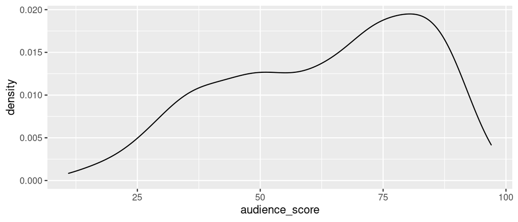

```r
movies %>% ggplot() +
  aes(x=audience_score) +
  geom_density()
```

Distribution of the `audience_score` is left skewed, without visible outliers.

### Regressors

#### `feature_film`

```r
movies %>%
  count(feature_film)
```

```
## # A tibble: 2 × 2
##   feature_film     n
##   <fct>        <int>
## 1 No              57
## 2 Yes            528
```

We can see that there are about 9 times more feature films than non-feature films.

`audience_score` vs `feature_film`

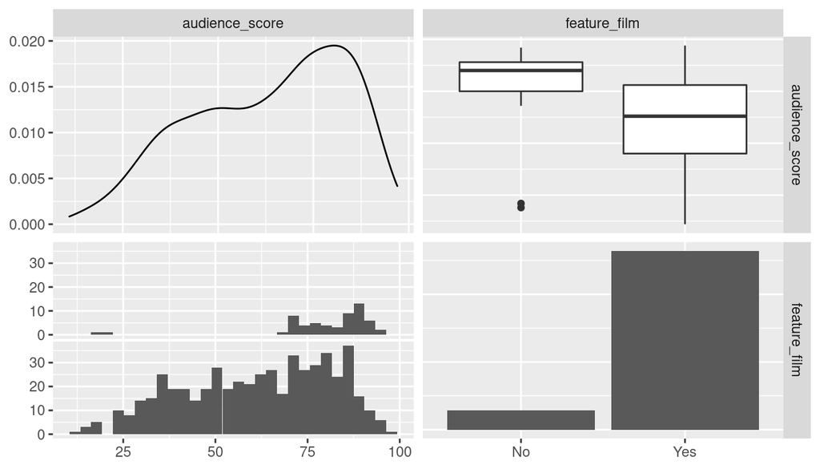

```r
ggpairs(movies,columns = c('audience_score','feature_film'))
```

We can see that median `audience_score` is noticeably different in the two groups.

#### `drama`

`drama` vs `audience_score`

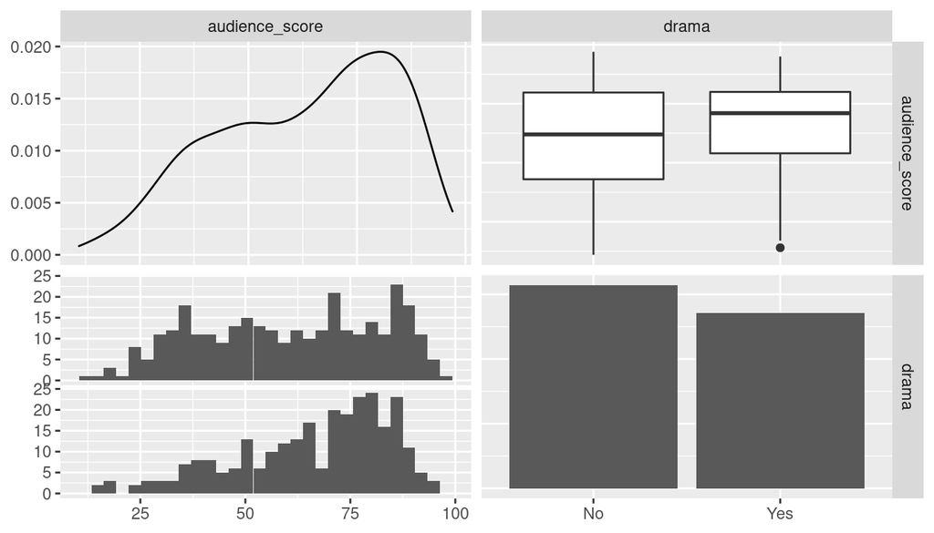

```r
ggpairs(movies,columns = c('audience_score','drama'))
```

We can see that drama/non-drama counts are almost equal. Median `audience_score` is noticeably different among the groups.

#### `runtime`

`runtime` vs `fin_score`

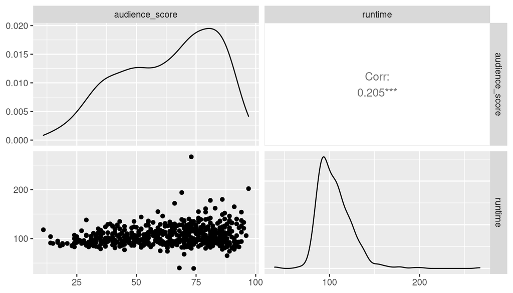

```r
ggpairs(movies,columns = c('audience_score','runtime'))
```

Distribution of `runtime` is right-skewed with some outliers. There is a heteroscedasticity, so let’s try a log transformation.

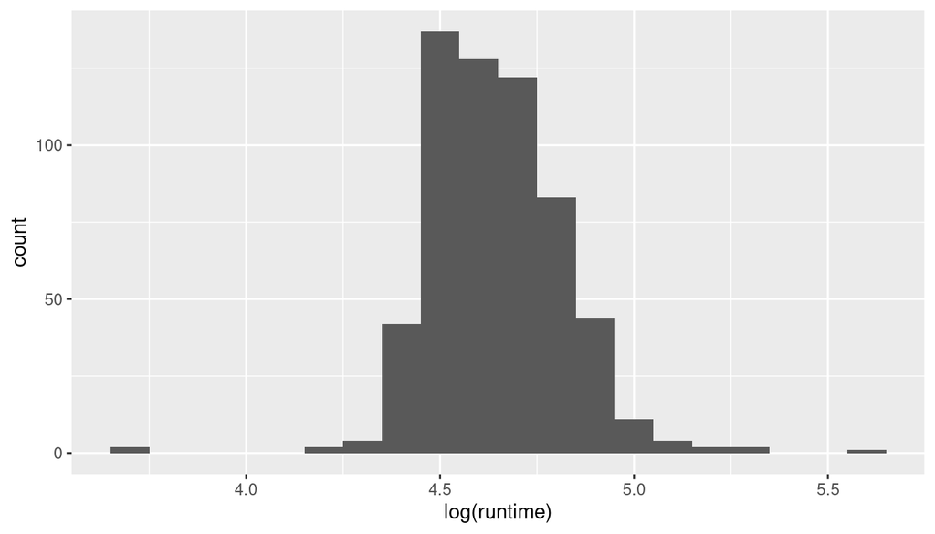

```r
movies %>% ggplot() +
  aes(x=log(runtime)) +
  geom_histogram(binwidth = 0.1)
```

We can see that after applying log transformation the distribution is more symmetric with a few outliers.

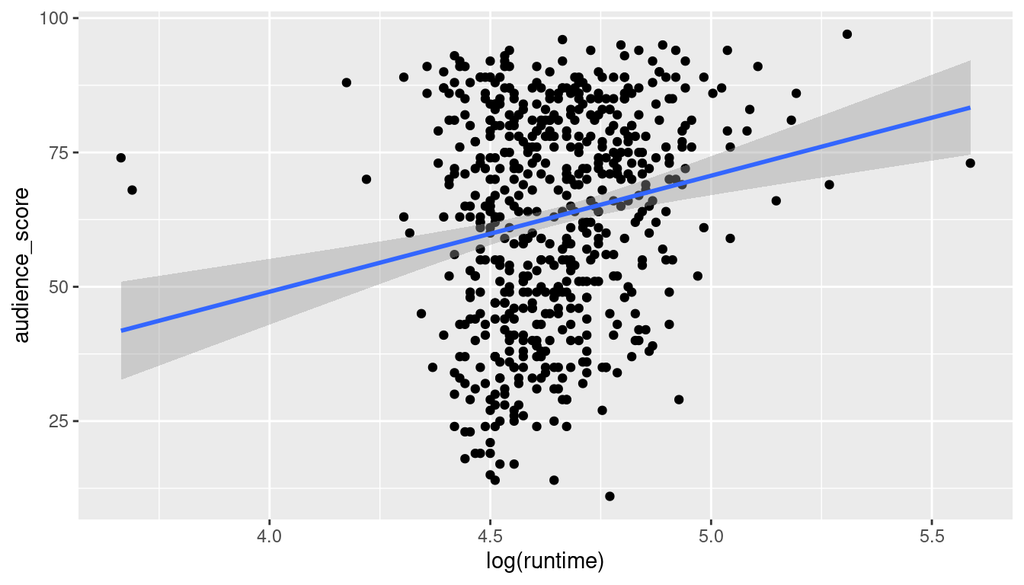

```r
movies %>% ggplot() +
  aes(x=log(runtime),y=audience_score) +
  geom_point() +
  geom_smooth(method='lm')
```

But unfortunately it does not help much with heteroscedasticity, but I will use it anyway because it makes distribution more symmetric and close to normal.

#### `mpaa_rating_R`

`mpaa_rating_R` vs `fin_score`

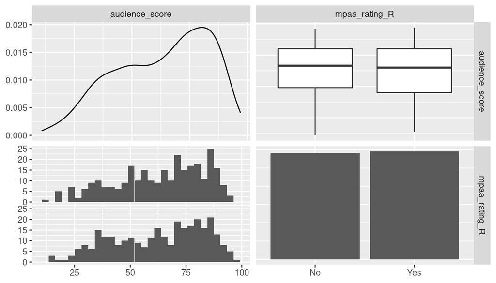

```r
ggpairs(movies,columns = c('audience_score','mpaa_rating_R'))
```

We can see that R/non-R mpaa rating counts are almost equal. I can not see any noticeable `audience_score` difference among the groups.

#### `thtr_rel_year`

Distribution of the `thtr_rel_year`

```r
summary(movies$thtr_rel_year)
```

```
##    Min. 1st Qu.  Median    Mean 3rd Qu.    Max.
##    1970    1991    2000    1998    2007    2014
```

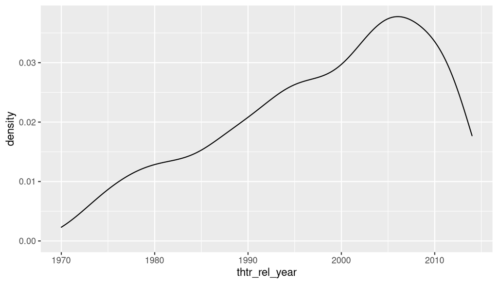

```r
movies %>% ggplot()+
  aes(x=thtr_rel_year) +
  geom_density()
```

We can see that there are not much movies released before 1980:

```r
ecdf(movies$thtr_rel_year)(1980)
```

```
## [1] 0.09059829
```

which can be the source of a bias.

`thtr_rel_year` vs `audience_score`

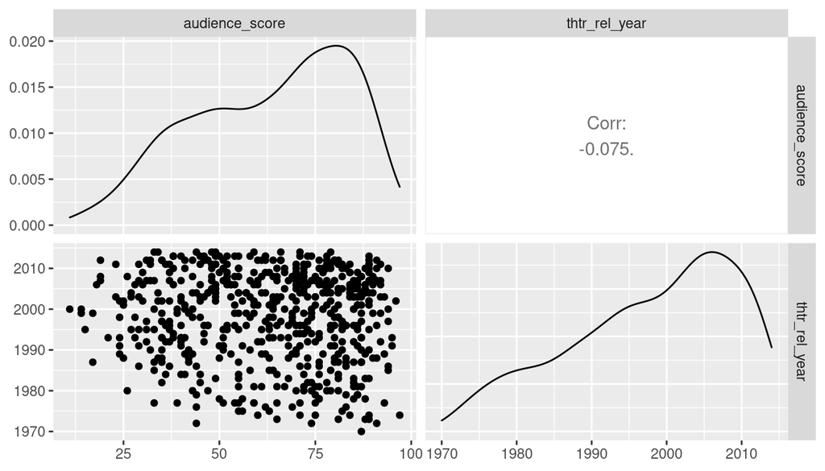

```r
ggpairs(movies,columns = c('audience_score','thtr_rel_year'))
```

We can see a weak negative correlation between `thtr_rel_year` and `audience_score`

#### `oscar_season`

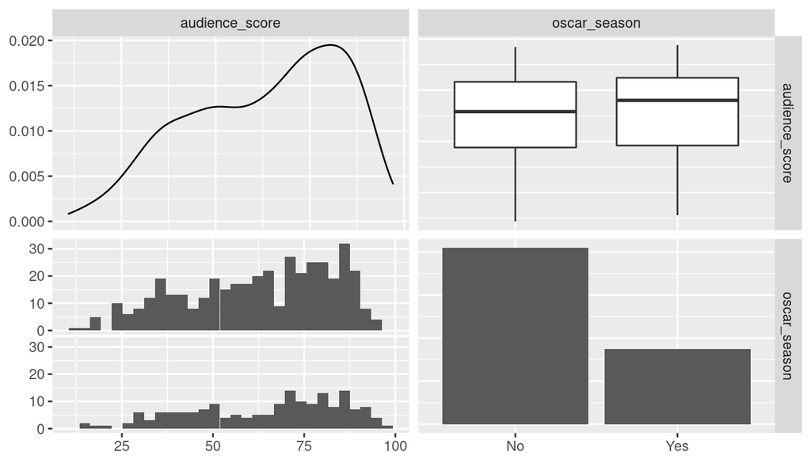

```r
ggpairs(movies,columns = c('audience_score','oscar_season'))
```

We can see pretty fair count among the groups (Oscar season consists of three months - November, October, December). We can see a noticeable difference for the median `audience_score` among the groups (higher for the Oscar season).

#### `summer_season`

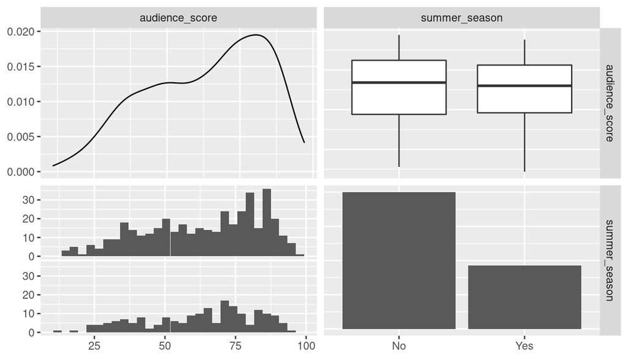

```r
ggpairs(movies,columns = c('audience_score','summer_season'))
```

We can see pretty fair count among the groups (Summer season consists of four months - May, June, July, August). We can see a small difference for the median `audience_score` among the groups (lower for the summer season).

#### `imdb_rating` and `critics_score`

I will **NOT** include `imdb_rating` variable in my analysis because it is basically the same thing as the response variable - the audience score from the different web site. Of course they will be highly correlated! It is not helpful in explaining the response variable at all. The prediction based on this variable also seems useless - if you see that a movie is popular on the IMDB it is obvious to see the same on the Rotten Tomatoes (the same US general audience). They have a slightly different distribution because of the calculation technique used at the Rotten Tomatoes. It is almost the same story with the `critics_score`, but the correlation is a bit less because critics in general have higher standards for the evaluation of a movie.

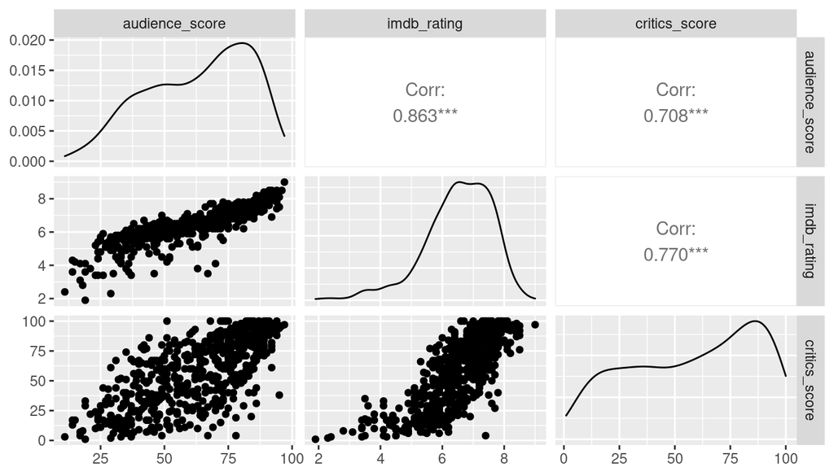

```r
ggpairs(movies,columns = c('audience_score','imdb_rating','critics_score'))
```

#### `imdb_num_votes`

`imdb_num_votes` vs `audience_score`

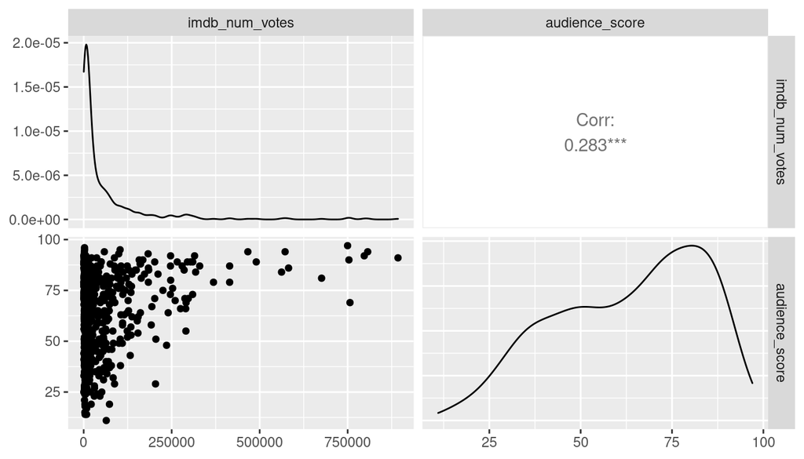

```r
ggpairs(movies,columns = c('imdb_num_votes','audience_score'))
```

Distribution of `imdb_num_votes` is heavily right-skewed with some outliers.

There is a significant heteroscedasticity. Let’s try log transformation.

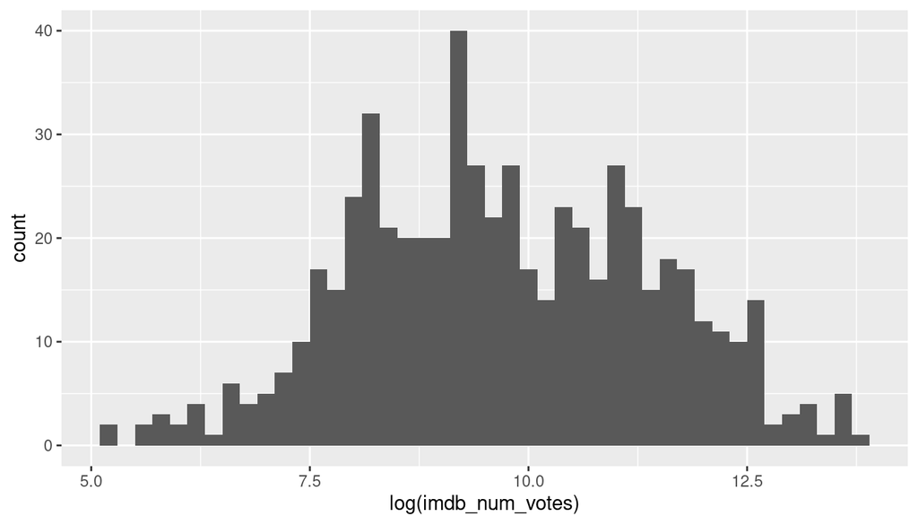

```r
movies %>% ggplot() +
  aes(x=log(imdb_num_votes)) +
  geom_histogram(binwidth = 0.2)
```

We can see that after applying log transformation the distribution is much more symmetric.

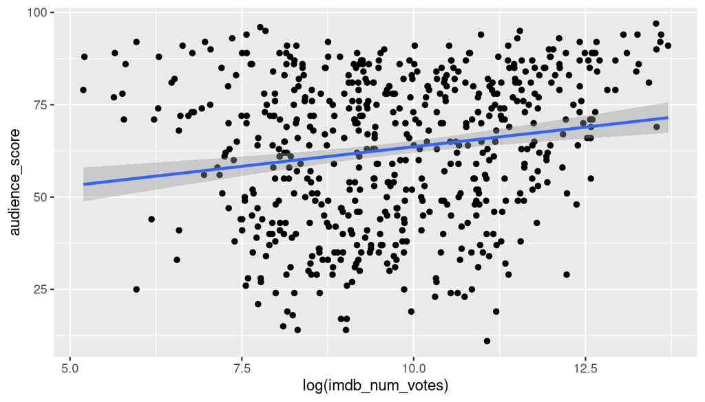

```r
movies %>% ggplot() +
  aes(x=log(imdb_num_votes),y=audience_score) +
  geom_point() +
  geom_smooth(method='lm')
```

We can see that heteroscedasticity also is much better after log transformation, so I will use it in the model

#### `best_pic_nom` and `best_pic_win`

`best_pic_nom` vs `audience_score`

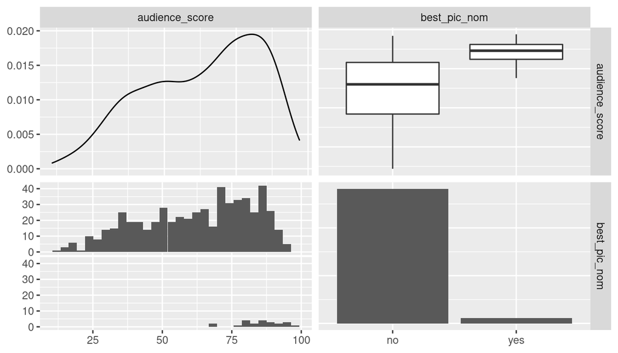

```r
ggpairs(movies, columns = c('audience_score','best_pic_nom'))
```

We can see that the medians differ substantially, but the number of nominated movies is very small.

```r
movies %>%
  count(best_pic_nom)
```

```
## # A tibble: 2 × 2
##   best_pic_nom     n
##   <fct>        <int>
## 1 no             563
## 2 yes             22
```

`best_pic_win` vs `audience_score`

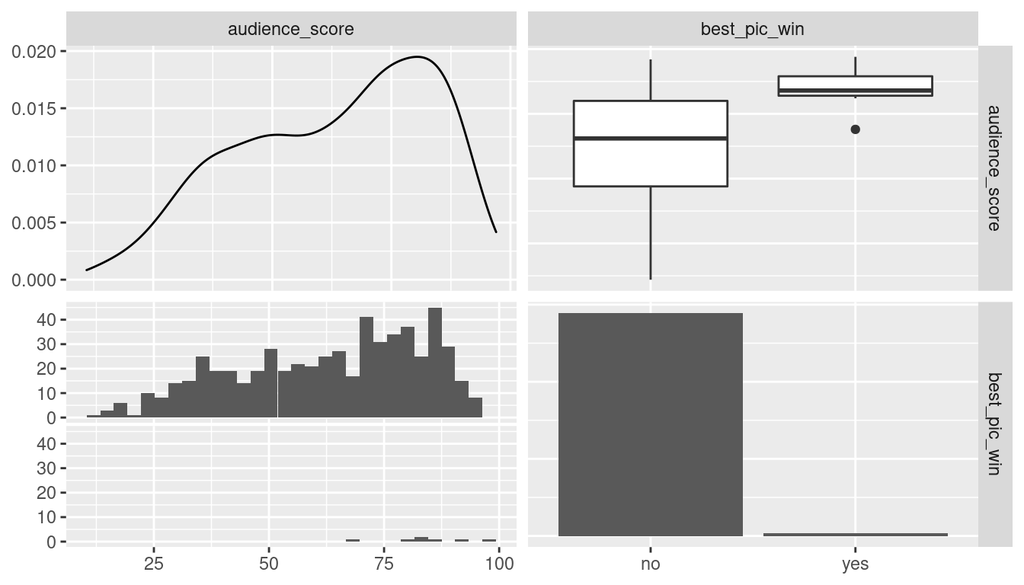

```r
ggpairs(movies, columns = c('audience_score','best_pic_win'))
```

We can see that the medians differ substantially, but the number of Oscar winners is tiny.

```r
movies %>%
  count(best_pic_win)
```

```
## # A tibble: 2 × 2
##   best_pic_win     n
##   <fct>        <int>
## 1 no             578
## 2 yes              7
```

#### `best_actor_win` and `best_actress_win`

I will create a new indicator variable `best_ac_win` which includes if any one of the gender wins

```r
movies <- movies %>%
  mutate(
    best_ac_win = if_else(best_actor_win=='yes' | best_actress_win=='yes','yes','no'))

movies_test <- movies_test %>%
  mutate(
    best_ac_win = if_else(best_actor_win=='yes' | best_actress_win=='yes','yes','no'))
```

`best_ac_win` vs `audience_score`

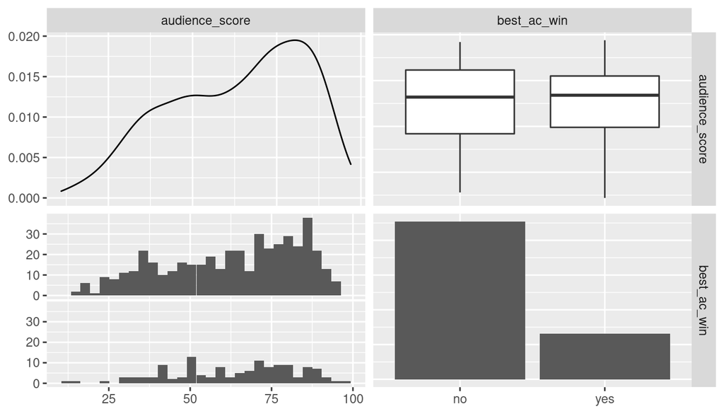

```r
ggpairs(movies, columns = c('audience_score','best_ac_win'))
```

I do not see any substantial difference in the medians here.

#### `best_dir_win`

`best_dir_win` vs `audience_score`

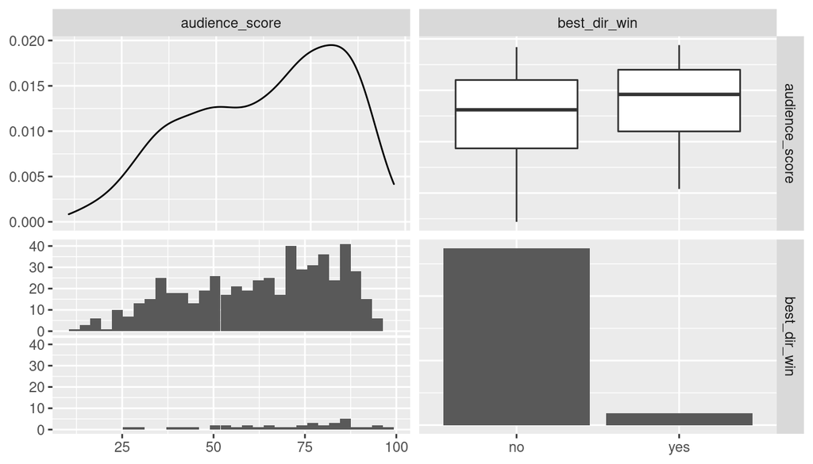

```r
ggpairs(movies, columns = c('audience_score', 'best_dir_win'))
```

We can see a difference in the means, but there are a small number of counts in the winner category.

#### `top200_box`

`top200_box` vs `audience_score`

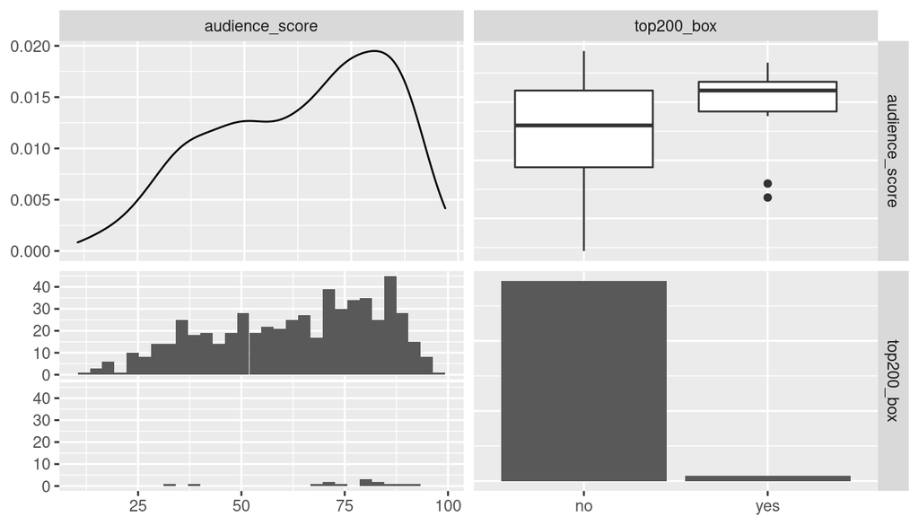

```r
ggpairs(movies, columns = c('audience_score','top200_box'))
```

We can see a difference in the medians, but there are too small counts in the ‘Yes’ category. Also there are two outliers.

#### `movies_short`

I will create a short version of the dataset containing only usable variables with all transformations.

```r
movies_short <- movies %>%
  select (
    audience_score,
    critics_score,
    feature_film,
    drama,
    runtime,
    mpaa_rating_R,
    thtr_rel_year,
    oscar_season,
    summer_season,
    imdb_num_votes,
    best_pic_nom,
    best_pic_win,
    best_ac_win,
    best_dir_win,
    top200_box ) %>%
  mutate(runtime = log(runtime), imdb_num_votes = log(imdb_num_votes))

movies_test <- movies_test %>%
  mutate(runtime = log(runtime), imdb_num_votes = log(imdb_num_votes))
```

## Part 4: Modeling

I have tried to incorporate interaction terms in the modeling but it did not work - r session was eating up all the memory and stopped responding. I have tried two methods of sampling - deterministic and MCMC. So I will use only the first order terms without interactions.

I will make three models - with reference prior using BIC and AIC approximation and Jeffreys-Zellner-Siow prior, compare them on test data and choose one which does the best job. As the ‘best single’ model I’m going to use BMA to incorporate variable inclusion uncertainty.

### Models

We have 14 variables which give us 2<sup>14</sup> models - it should be easy to enumerate them. For reference prior I will use BIC and AIC for approximation. For Jeffreys-Zellner-Siow prior I will use the ‘EB-local’ method which uses the MLE of g from the marginal likelihood within each model.

```r
#Reference prior with BIC
model.BIC <-  bas.lm(audience_score ~ ., data=movies_short,
                   prior='BIC', modelprior=uniform())

#Reference prior with AIC
model.AIC <-  bas.lm(audience_score ~ ., data=movies_short,
                   prior='AIC', modelprior=uniform())

# Empirical Bayesian estimation under maximum marginal likelihood
model.EB <- bas.lm(audience_score ~ ., data=movies_short, prior='EB-local',
                a=nrow(movies_short), modelprior=uniform())
```

### Comparing posterior inclusion probability (PIP)

Let’s compare the PIP of predictors in each of three models.

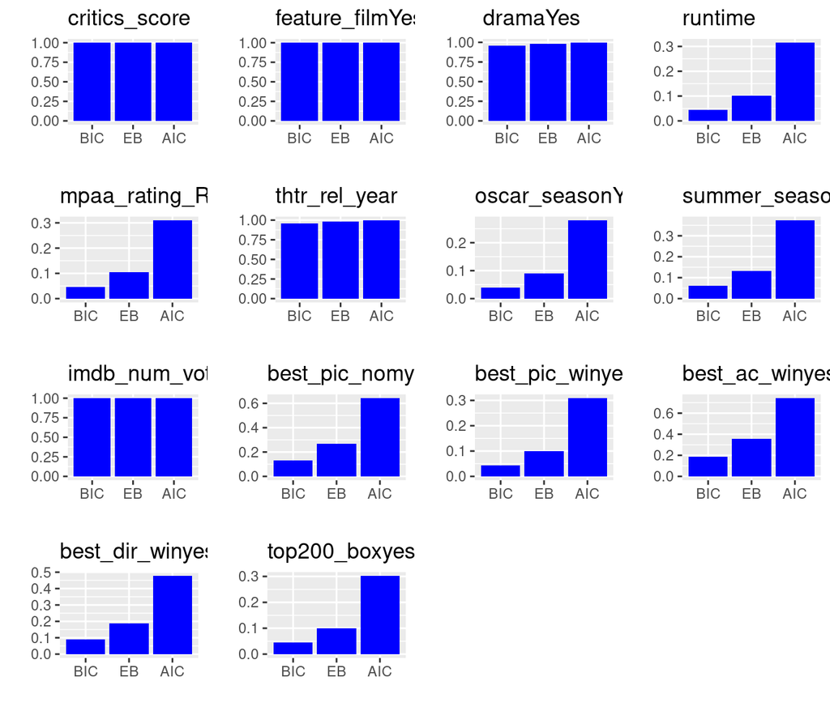

```r
probne0 <- cbind(model.BIC$probne0, model.EB$probne0, model.AIC$probne0)
colnames(probne0) <- c('BIC', 'EB', 'AIC')
rownames(probne0) <- c(model.BIC$namesx)

# Generate plot for each variable and save in a list
plt_list <- list()
for (i in 2:15){
  df <- data.frame(prior = colnames(probne0), posterior = probne0[i, ])
  df$prior <- factor(df$prior, levels = colnames(probne0))
  plt <- ggplot(df, aes(x = prior, y = posterior)) +
          geom_bar(stat = 'identity', fill = 'blue') + xlab('') +
          ylab('') +
          ggtitle(model.BIC$namesx[i])
  plt_list <- c(plt_list, list(plt))
}

do.call(plot_grid, c(plt_list))
```

We can see that these three models do agree on some of the variables with high pip - `critics_score`, `future_film`, `drama`, `thtr_rel_year` and `imdb_num_votes`. For the other variables - BIC model is the most conservative, AIC the most inclusive and EB somewhere in the middle. Let’s compare their predictive power.

### Comparing predictive power

```r
#function to calculate metrics
calc_metrics <- function(model.name,newdata,response.var) {
  argg <- as.list(environment())
  pred <- predict(model.name,newdata = newdata,estimator = 'BMA')
  act_pred <- data.frame(cbind(act=response.var, pred=pred$fit))

  MSE <- mean((act_pred$act - act_pred$pred)^2,na.rm=T)
  efR <- 1 - sum( (act_pred$act - act_pred$pred)^2 ,na.rm=T)/
    sum( (act_pred$act-mean(act_pred$act,na.rm=T))^2 ,na.rm=T)

  df <- data.frame(deparse(substitute(model.name)),round(MSE,4),round(efR,4))
  names(df) <- c('Model','MSE','EfronsR^2')
  return(df)
}

#metrics for all the models
res_table <- calc_metrics(model.BIC,movies_test,movies_test$audience_score)
res_table <- rbind(res_table,calc_metrics(model.AIC,movies_test,movies_test$audience_score))
res_table <- rbind(res_table,calc_metrics(model.EB,movies_test,movies_test$audience_score))
res_table
```

```
##       Model      MSE EfronsR^2
## 1 model.BIC 226.0514    0.3285
## 2 model.AIC 225.5069    0.3301
## 3  model.EB 224.9494    0.3318
```

According to the prediction accuracy the best model is `model.EB` (smallest MSE and biggest Efron’s R<sup>2</sup>). I will use this model for further exploration.

### The best model

#### Summary of the BMA

```r
summary(model.EB)
```

```
##                  P(B != 0 | Y)  model 1    model 2     model 3     model 4
## Intercept           1.00000000   1.0000   1.000000   1.0000000   1.0000000
## critics_score       1.00000000   1.0000   1.000000   1.0000000   1.0000000
## feature_filmYes     0.99999986   1.0000   1.000000   1.0000000   1.0000000
## dramaYes            0.97949013   1.0000   1.000000   1.0000000   1.0000000
## runtime             0.10126851   0.0000   0.000000   0.0000000   0.0000000
## mpaa_rating_RYes    0.10358449   0.0000   0.000000   0.0000000   0.0000000
## thtr_rel_year       0.97903810   1.0000   1.000000   1.0000000   1.0000000
## oscar_seasonYes     0.09015450   0.0000   0.000000   0.0000000   0.0000000
## summer_seasonYes    0.13118825   0.0000   0.000000   0.0000000   0.0000000
## imdb_num_votes      0.99999999   1.0000   1.000000   1.0000000   1.0000000
## best_pic_nomyes     0.26762640   0.0000   0.000000   1.0000000   0.0000000
## best_pic_winyes     0.09872250   0.0000   0.000000   0.0000000   0.0000000
## best_ac_winyes      0.35922591   0.0000   1.000000   0.0000000   0.0000000
## best_dir_winyes     0.18827363   0.0000   0.000000   0.0000000   1.0000000
## top200_boxyes       0.09966157   0.0000   0.000000   0.0000000   0.0000000
## BF                          NA   1.0000   0.447278   0.2534963   0.2111533
## PostProbs                   NA   0.2159   0.096600   0.0547000   0.0456000
## R2                          NA   0.5547   0.557200   0.5563000   0.5561000
## dim                         NA   6.0000   7.000000   7.0000000   7.0000000
## logmarg                     NA 220.8793 220.074681 219.5068504 219.3240854
##                      model 5
## Intercept          1.0000000
## critics_score      1.0000000
## feature_filmYes    1.0000000
## dramaYes           1.0000000
## runtime            0.0000000
## mpaa_rating_RYes   0.0000000
## thtr_rel_year      1.0000000
## oscar_seasonYes    0.0000000
## summer_seasonYes   0.0000000
## imdb_num_votes     1.0000000
## best_pic_nomyes    1.0000000
## best_pic_winyes    0.0000000
## best_ac_winyes     1.0000000
## best_dir_winyes    0.0000000
## top200_boxyes      0.0000000
## BF                 0.2065758
## PostProbs          0.0446000
## R2                 0.5597000
## dim                8.0000000
## logmarg          219.3021688
```

From this output we can see that most significant variables are: `critics_score` with the inclusion probability 1, `feature_film` with the inclusion probability close to 1, `drama` with the inclusion probability 0.979, `thtr_rel_year` with the inclusion probability 0.979, `imdb_num_votes` with inclusion probability close to 1.

Moderately significant variables are: `best_pic_nom` with the inclusion probability 0.268, `best_ac_winyes` with the inclusion probability 0.359 and best_dir_win with the inclusion probability 0.188

Other variables have the inclusion probability less than 0.15.

#### Credible intervals of the $\beta$s

```r
model.EB.coefs = coef(model.EB)
confint(model.EB.coefs)
```

```
##                         2.5%        97.5%          beta
## Intercept         61.9403964  64.13224393  63.008561644
## critics_score      0.3651005   0.45670727   0.409236459
## feature_filmYes  -21.7924943 -11.69153677 -16.754737210
## dramaYes           1.6614011   6.95151612   4.254761281
## runtime           -0.3100391   4.27415762   0.184871191
## mpaa_rating_RYes  -1.4582341   0.14028955  -0.070290031
## thtr_rel_year     -0.3232111  -0.07827871  -0.195584038
## oscar_seasonYes   -0.8895692   0.53577376  -0.007703403
## summer_seasonYes  -2.0388210   0.00000000  -0.151720599
## imdb_num_votes     2.1698787   3.84241674   2.983043659
## best_pic_nomyes    0.0000000   8.65839701   1.398405698
## best_pic_winyes   -5.1446555   2.01699080  -0.195609342
## best_ac_winyes    -4.3884518   0.00000000  -0.949490628
## best_dir_winyes   -5.3497677   0.03717784  -0.594268901
## top200_boxyes     -4.3125242   0.74083401  -0.194166863
## attr(,"Probability")
## [1] 0.95
## attr(,"class")
## [1] "confint.bas"
```

There is a very interesting results among this group of variables - `best_pic_nom`, `best_pic_win`, `best_ac_win`, `best_dir_win` and `top200_box` - only the first one `best_pic_nom` - has positive correlation with the response variables, others have mixed or negative correlation. This could be because of the collinearity between them. We can see this data in the visual form below

#### Plots of the $\beta$s

Posterior Uncertainty in Coefficients

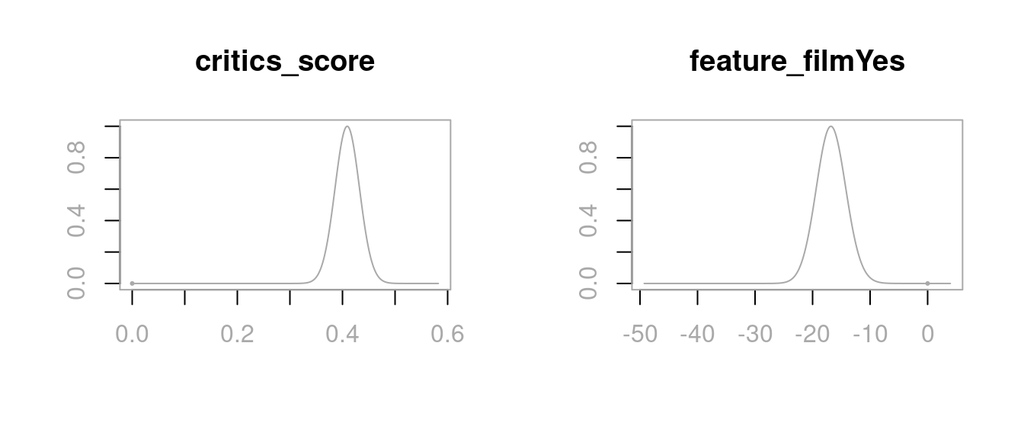

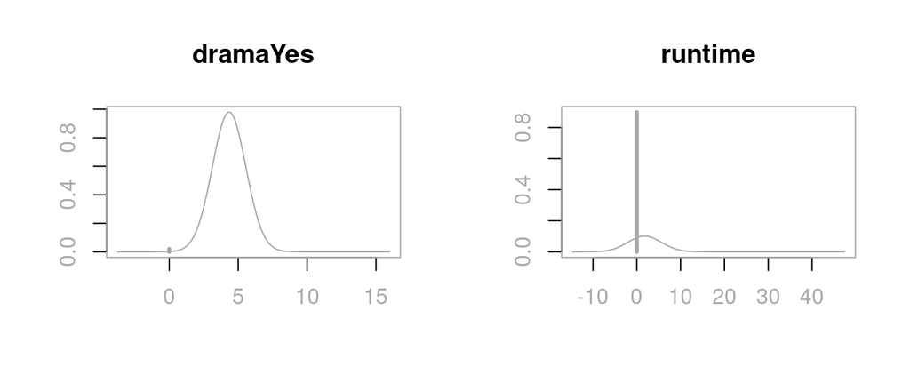

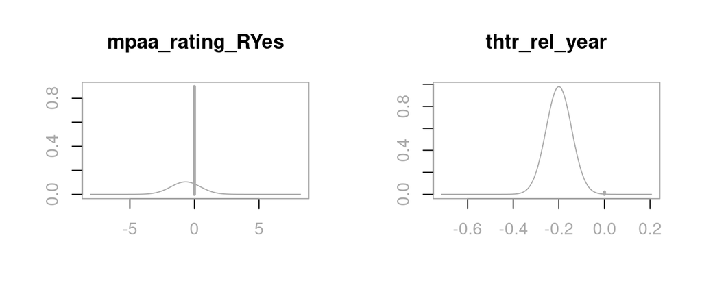

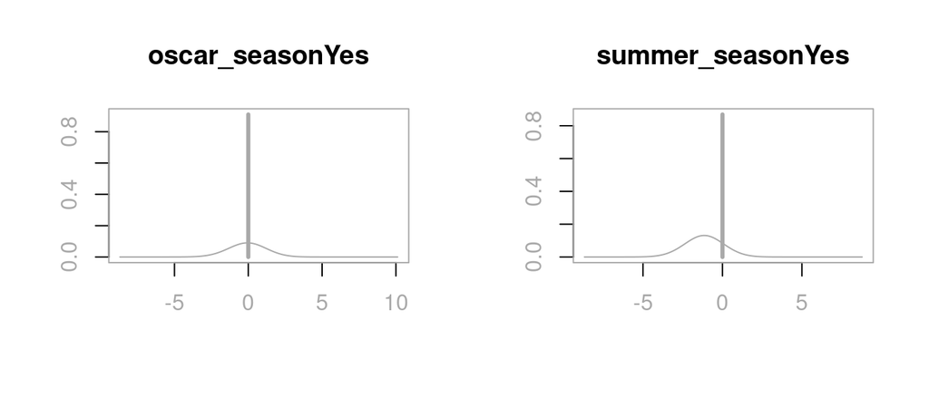

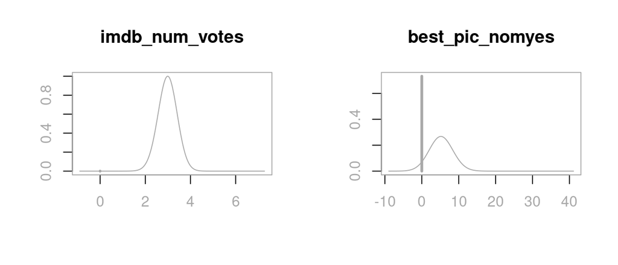

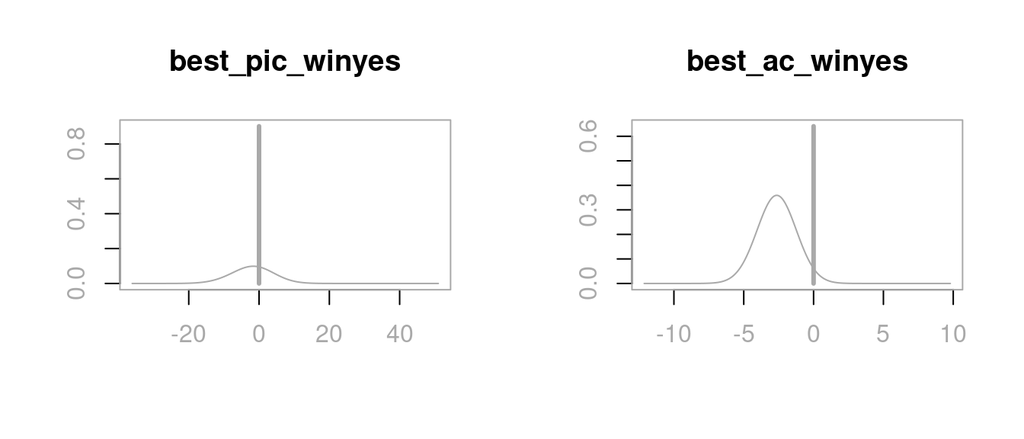

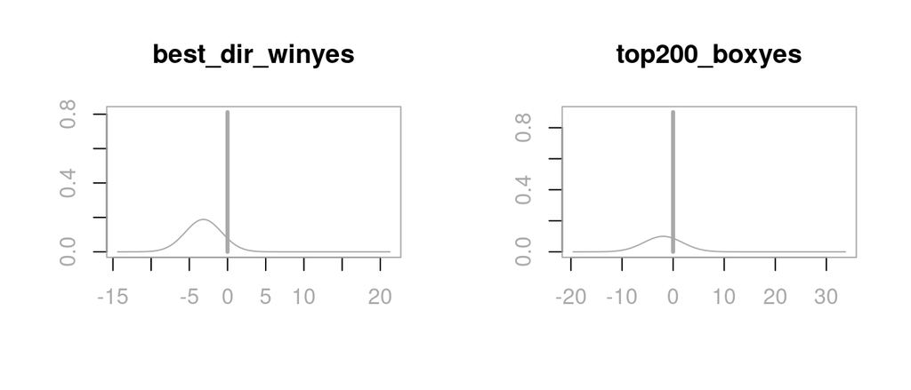

```r
par(mfrow = c(1, 2), col.lab = 'darkgrey', col.axis = 'darkgrey', col = 'darkgrey')
plot(model.EB.coefs, ask = F, subset = c(2:15))
```

#### Model space

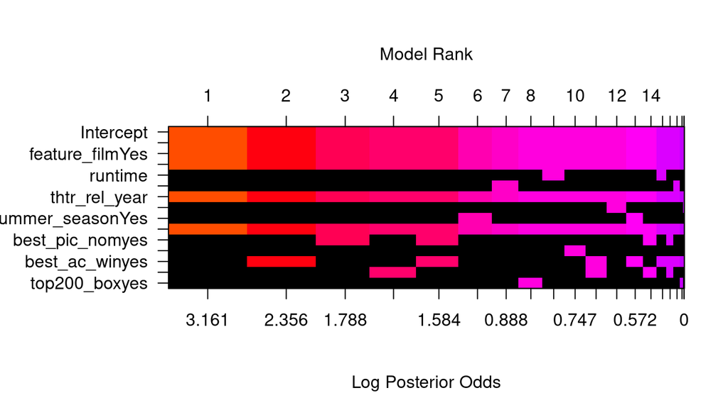

```r
image(model.EB, rotate = F,vlas = 2,plas = 0)
```

We can see that the posterior odds have considerable differences between the first three models and they differ only in one variable from each other.

### Best single model

#### Highest Probability Model

If our objective is to learn what is the most likely model to have generated the data using a 0-1 loss function, then the highest probability model (HPM) is optimal.

```r
model.EB.HPM <- predict(model.EB, estimator = 'HPM')
model.EB.HPM$best.vars
```

```
## [1] "Intercept"       "critics_score"   "feature_filmYes" "dramaYes"
## [5] "thtr_rel_year"   "imdb_num_votes"
```

We can see that HPM has 5 variables not including intercept.

Let’s see its posterior means of coefficients:

```r
coef(model.EB, estimator='HPM')
```

```
##
##  Marginal Posterior Summaries of Coefficients:
##
##  Using  HPM
##
##  Based on the top  1 models
##                   post mean  post SD    post p(B != 0)
## Intercept          63.00856    0.55715    1.00000
## critics_score       0.40980    0.02277    1.00000
## feature_filmYes   -16.98883    2.51908    1.00000
## dramaYes            4.29026    1.19816    0.97949
## runtime             0.00000    0.00000    0.10127
## mpaa_rating_RYes    0.00000    0.00000    0.10358
## thtr_rel_year      -0.19830    0.05565    0.97904
## oscar_seasonYes     0.00000    0.00000    0.09015
## summer_seasonYes    0.00000    0.00000    0.13119
## imdb_num_votes      2.98194    0.40273    1.00000
## best_pic_nomyes     0.00000    0.00000    0.26763
## best_pic_winyes     0.00000    0.00000    0.09872
## best_ac_winyes      0.00000    0.00000    0.35923
## best_dir_winyes     0.00000    0.00000    0.18827
## top200_boxyes       0.00000    0.00000    0.09966
```

If we compare them to the BMA (`feature_filmYes = -16.7547, dramaYes = 4.2548, thtr_rel_year = -0.1956, imdb_num_votes = 2.9830`) we can see that they are almost identical which suggests the stability of the model.

We can also obtain the posterior probability of this model:

```r
model.EB$postprobs[model.EB.HPM$best]
```

```
## [1] 0.2159378
```

The posterior probability is quite high for a single model.

#### Median Probability Model

This model includes all predictors whose marginal posterior inclusion probabilities are greater than 0.5.

```r
model.EB.MPM = predict(model.EB, estimator = 'MPM')
model.EB.MPM$best.vars
```

```
## [1] "Intercept"       "critics_score"   "feature_filmYes" "dramaYes"
## [5] "thtr_rel_year"   "imdb_num_votes"
```

We can see that variables are the same as for the HPM.

Let’s look at the posterior means of coefficients:

```r
coef(model.EB, estimator='MPM')
```

```
##
##  Marginal Posterior Summaries of Coefficients:
##
##  Using  MPM
##
##  Based on the top  1 models
##                   post mean  post SD    post p(B != 0)
## Intercept          63.00856    0.55715    1.00000
## critics_score       0.40980    0.02277    1.00000
## feature_filmYes   -16.98883    2.51908    1.00000
## dramaYes            4.29026    1.19816    1.00000
## runtime             0.00000    0.00000    0.00000
## mpaa_rating_RYes    0.00000    0.00000    0.00000
## thtr_rel_year      -0.19830    0.05565    1.00000
## oscar_seasonYes     0.00000    0.00000    0.00000
## summer_seasonYes    0.00000    0.00000    0.00000
## imdb_num_votes      2.98194    0.40273    1.00000
## best_pic_nomyes     0.00000    0.00000    0.00000
## best_pic_winyes     0.00000    0.00000    0.00000
## best_ac_winyes      0.00000    0.00000    0.00000
## best_dir_winyes     0.00000    0.00000    0.00000
## top200_boxyes       0.00000    0.00000    0.00000
```

The coefficients are also the same as in the HPM.

#### Best Predictive Model

This is a model whose predictions are closest to those given by BMA based on squared error loss for predictions.

```r
model.EB.BPM <- predict(model.EB, estimator = 'BPM')
model.EB.BPM$best.vars
```

```
## [1] "Intercept"       "critics_score"   "feature_filmYes" "dramaYes"
## [5] "thtr_rel_year"   "oscar_seasonYes" "imdb_num_votes"
```

We can see here additional variable `oscar_season` compare to HPM and MPM

Because the `coef()` function is not yet implemented for this model we have to extract coefficients manually.

```r
# Extract a binary vector of zeros and ones for the variables included
# in the BPM
BPM <- as.vector(which.matrix(model.EB$which[model.EB.BPM$best],
                             model.EB$n.vars))

# Re-run regression and specify `bestmodel` and `n.models`
model.EB.BPM_re <- bas.lm(audience_score ~ ., data = movies_short,
                      prior = 'EB-local',
                      modelprior = uniform(),
                      bestmodel = BPM, n.models = 1)

coef(model.EB.BPM_re)
```

```
##
##  Marginal Posterior Summaries of Coefficients:
##
##  Using  BMA
##
##  Based on the top  1 models
##                   post mean  post SD    post p(B != 0)
## Intercept          63.00856    0.55763    1.00000
## critics_score       0.40922    0.02277    1.00000
## feature_filmYes   -16.96575    2.52005    1.00000
## dramaYes            4.28504    1.19937    1.00000
## runtime             0.00000    0.00000    0.00000
## mpaa_rating_RYes    0.00000    0.00000    0.00000
## thtr_rel_year      -0.19810    0.05584    1.00000
## oscar_seasonYes    -0.02102    1.22336    1.00000
## summer_seasonYes    0.00000    0.00000    0.00000
## imdb_num_votes      2.97832    0.40428    1.00000
## best_pic_nomyes     0.00000    0.00000    0.00000
## best_pic_winyes     0.00000    0.00000    0.00000
## best_ac_winyes      0.00000    0.00000    0.00000
## best_dir_winyes     0.00000    0.00000    0.00000
## top200_boxyes       0.00000    0.00000    0.00000
```

We can see that coefficients are very similar to HPM and MPM as well.

From comparing all 4 models we can see that main variables are uncorrelated and the model is very stable in coefficients. In further analysis I’m going to use the BMA model.

### Diagnostics

#### OLS assumptions

1. $\epsilon$ is a random variable that does not depend on X - ‘perfect model’

   Residual plot shows a pattern?
2. $E(\epsilon)=0$ (always true for a model with an intercept)
3. All $\epsilon_i$ are independent of each other (they are uncorrelated for the population, but not for the sample)
4. $\epsilon \sim N(0,\theta_\epsilon)$ Residuals and $y_i$ are normally distributed

   They are not perfectly normal, but it will do for now.
5. all $\epsilon_i$ have the same PDF - homoscedasticity

   There is some heteroscedasticity, but it will do for now.

#### Outliers

Let’s assume prior probability of no outliers in the sample 0.95, then:

```r
#outlier criterion k*SE
k = qnorm(0.5 + 0.5*(0.95^(1/nrow(movies_short))))

#predicted values
pred <- predict(model.EB,estimator = 'BMA', se=TRUE)

MSE <- mean((movies_short$audience_score - pred$fit)^2,na.rm=T)

#standardized residuals
resid_norm <- (movies_short$audience_score - pred$fit)/sqrt(MSE)

#if there any residuals more than K standard errors away
resid_norm[abs(resid_norm) > k]
```

```
## numeric(0)
```

According to `Bayes.outlier()` function, there are no outliers with posterior probability more than 0.5 as well.

```r
model.lm = lm(audience_score~., data=movies_short)

outliers <- Bayes.outlier(model.lm, k=k)

outliers_df <- data.frame(probability = outliers$prob.outlier,
                          case = 1:length(outliers$prob.outlier))
outliers_df %>%
  filter(probability > 0.50)
```

```
## [1] probability case
## <0 rows> (or 0-length row.names)
```

```r
head(outliers_df)
```

```
##     probability case
## 1  8.033782e-72    1
## 2 8.334486e-194    2
## 3 1.470413e-269    3
## 4 3.320782e-217    4
## 5  0.000000e+00    5
## 6 5.116510e-110    6
```

#### Diagnostic plots

##### Residuals vs fitted

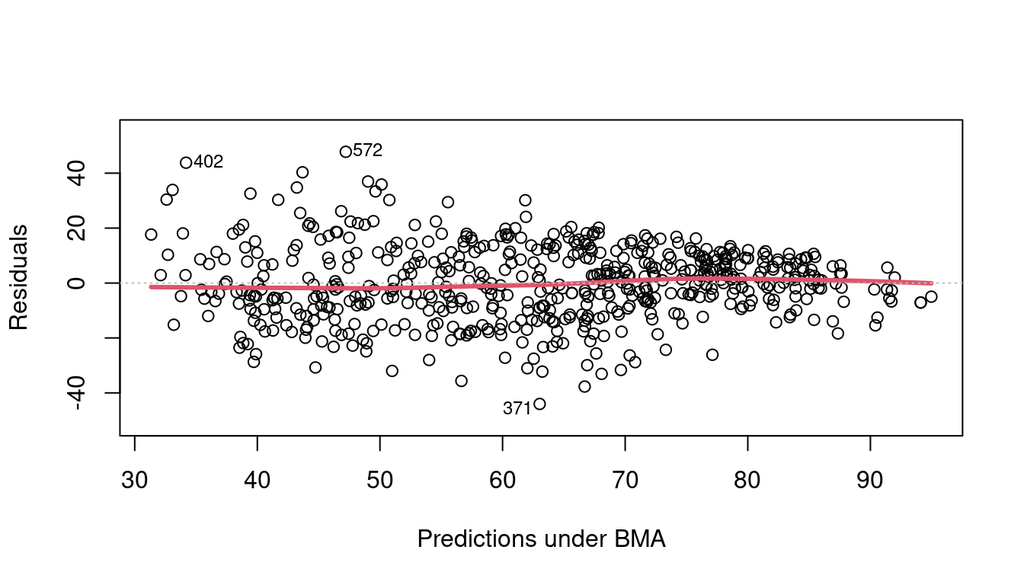

```r
plot(model.EB,caption = '', sub.caption = '',
     col.in = 'blue', col.ex = 'darkgrey', lwd = 3, ask = F, which=1 )
```

plot of residuals and fitted values under Bayesian Model Averaging. We see potential outliers - cases 402, 572 and 371 and non-constant variance. This outliers result differs from what I calculated above in the ‘Outliers’ section. This needs further investigation. Also there is a slightly non-linear trend, but it should not be a major problem.